# Exam 1

## Exam 1

#### Question

1. Using the `diamonds` dataset, complete the code below to generate the target plot below. The plot is using a log with base 10 transformation on the y-axis, a square-root transformation on the x-axis and the color is using the default viridis palette. **For any function names, write the full function name without any bracket in your answer.**

   ```
   data(diamonds, package = "ggplot2")
   str(diamonds)
   ```

   ```
   ## tibble [53,940 × 10] (S3: tbl_df/tbl/data.frame)
   ##  $ carat  : num [1:53940] 0.23 0.21 0.23 0.29 0.31 0.24 0.24 0.26 0.22 0.23 ...
   ##  $ cut    : Ord.factor w/ 5 levels "Fair"<"Good"<..: 5 4 2 4 2 3 3 3 1 3 ...
   ##  $ color  : Ord.factor w/ 7 levels "D"<"E"<"F"<"G"<..: 2 2 2 6 7 7 6 5 2 5 ...
   ##  $ clarity: Ord.factor w/ 8 levels "I1"<"SI2"<"SI1"<..: 2 3 5 4 2 6 7 3 4 5 ...
   ##  $ depth  : num [1:53940] 61.5 59.8 56.9 62.4 63.3 62.8 62.3 61.9 65.1 59.4 ...
   ##  $ table  : num [1:53940] 55 61 65 58 58 57 57 55 61 61 ...
   ##  $ price  : int [1:53940] 326 326 327 334 335 336 336 337 337 338 ...
   ##  $ x      : num [1:53940] 3.95 3.89 4.05 4.2 4.34 3.94 3.95 4.07 3.87 4 ...
   ##  $ y      : num [1:53940] 3.98 3.84 4.07 4.23 4.35 3.96 3.98 4.11 3.78 4.05 ...
   ##  $ z      : num [1:53940] 2.43 2.31 2.31 2.63 2.75 2.48 2.47 2.53 2.49 2.39 ...
   ```

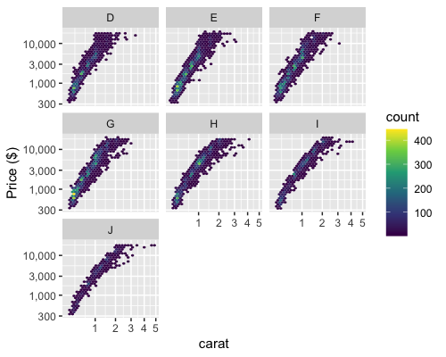

   ```r
   ggplot(diamonds, aes(x = ___, y = price)) +
     geom____() +
     facet_wrap(~___) +
     scale____(name = "___", labels = scales::comma) +
     scale____() +
     scale_____viridis_c()
   ```

   1. What is the name of the variable that is mapped to `x` in `aes`?
   2. What is the full function name for the layer function?
   3. What is the variable used to facet the plot into multiple subplots?
   4. What is the scale function used to transform the y-axis into a log with base 10 scale?
   5. What is the label for the y-axis? (No quotation is needed in your answer.)
   6. What is the scale function used to apply a square-root transformation the x-axis?
   7. What is the scale function used to modify the palette used to viridis?

#### Solution

   1. `x = carat`
   2. The layer function is `geom_hex`.
   3. The variable `color` is used for faceting.
   4. The scale function for the y-axis is `scale_y_log10`.
   5. The label for the y-axis is “Price ($)”.
   6. The scale function for the x-axis is `scale_x_sqrt`.
   7. Notice here the legend is showing the `fill` color. So the scale function for the fill is `scale_fill_viridis_c`.